# Handling the peculiarities of marine movement data

Marie Auger-Méthé

# 1 Credits

This tutorial uses materials that was created by the CANSSI Collaborative Research Team led by Vianey Leos Barajas and Marie Auger-Méthé. I thank Fanny Dupont, Ron Togunov, Natasha Klappstein, Arturo Esquivel, Marco Gallegos Herrada, and Sofia Ruiz Suarez for their contribution to this original material.

# 2 Tutorial goals

The goal of this tutorial is to explore ways to pre-prepare marine movement data. The primary learning objectives are to:

1. Regularize movement tracks that are irregular using Fastloc GPS data as an example.
2. Create predicted tracks from error-prone data using Argos data as an example.

# 3 General setup

First, let’s load the packages that we will need to complete the analyses. Of course you need to have them installed first.

```r
library(momentuHMM) # Package for fitting HMMs, we use it for crawlWrap
library(tidyverse)  # data management
library(ggspatial)  # plot the data
library(sf)         # spatial data processing
library(kableExtra) # produce visually appealing tables
library(geosphere)  # to calculate step lengths from lat/lon locations - just need it installed
library(conicfit)   # needs to be installed for crawlWrap
library(here)       # To help with sourcing
library(adehabitatLT) # setNA
library(terra)
library(tidyterra)
library(aniMotum)
library(mitools)  # used by mometuHMM, just need to be installed

# install.packages("aniMotum",
#                  repos = c("https://cloud.r-project.org",
#                  "https://ianjonsen.r-universe.dev"),
#                  dependencies = TRUE)
```

We are assuming that you are working from Madeira-Workshop repository main folder, and using `here()` to help find the good directory for each files. We will need the functions in the following file `utility_functions.R`.

```r
source(here("D1-data-prep-ssm",
            "utility_functions.R"))
```

# 4 Regularising Fastloc GPS data

## 4.1 Narwhal movement data

We will analyze a dataset containing movement tracks of three narwhals tagged with Fastloc-GPS tags. The dataset was provided by Dr. Marianne Marcoux (Fisheries and Oceans, Canada). Dr. Marcoux provided the data only for this tutorial, please do not use for other purposes without their consent. Contact: Marianne.Marcoux@dfo-mpo.gc.ca.

For simplicity, we only examine the fastloc-GPS data from one week in August 2017.

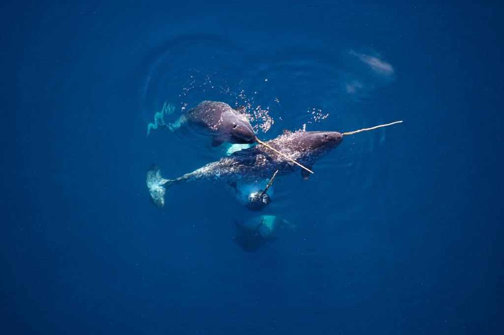

Photo by Paul Nicklen

First, let’s import the raw Fastloc GPS narwhal data and convert the time column to an appropriate date format.

```r
tracks_gps_O <- read.csv(here("D1-data-prep-ssm", "data", "tracks_fastloc_gps.csv")) %>%
  mutate(time = ymd_hms(time),
         ID = factor(ID))
```

We can have a first look at the data, to get more familiar with it.

```r
head(tracks_gps_O)
```

```
##        ID                time        x       y loc_class
## 1 T172062 2017-08-08 00:00:00 -80.6414 72.2694       GPS
## 2 T172062 2017-08-08 00:20:00 -80.6525 72.2728       GPS
## 3 T172062 2017-08-08 00:42:00 -80.6665 72.2719       GPS
## 4 T172062 2017-08-08 00:52:00 -80.6692 72.2674       GPS
## 5 T172062 2017-08-08 01:09:00 -80.6682 72.2582       GPS
## 6 T172062 2017-08-08 01:19:00 -80.6613 72.2574       GPS
```

The columns/variables are:

- `ID`: Individual identifier
- `time`: time of location
- `x`: longitude
- `y`: latitude
- `loc_class`: all GPS

The data we obtain is often quite messy with some rows/records missing information and other records duplicated. We can filter records to keep only complete location data using `!is.na(x) & !is.na(y)`. To remove duplicate records (same time, location, and location class), we will use the `lag` function from `dplyr`, which will use the value from the previous row so that we can compare to the current row.

```r
tracks_gps_O <- tracks_gps_O %>%
  # remove missing locations
  filter(!is.na(x) & !is.na(y),
         # remove identical records
         !(time == lag(time) &
             x == lag(x) &
             y == lag(y) &
             loc_class == lag(loc_class)))
```

Let’s plot the data over the bathymetry (i.e., depth of the ocean) and land layers, to get a sense of where these narwhals are swimming.

```r
land <- st_read(here("D1-data-prep-ssm", "data", "NorthBaffin.shp"))
```

The raw bathymetry data used to create this raster was taken from the the GEBCO global ocean and land terrain model from https://pressbooks.bccampus.ca/ewemodel/chapter/getting-bathymetry/. Note that land values of the bathymetry layer are 0s.

```r
bathy <- rast(here("D1-data-prep-ssm", "data", "bathy_4_narwhals.tiff"))
```

Let’s plot the narwhal movement data over the bathymetry and land layers.

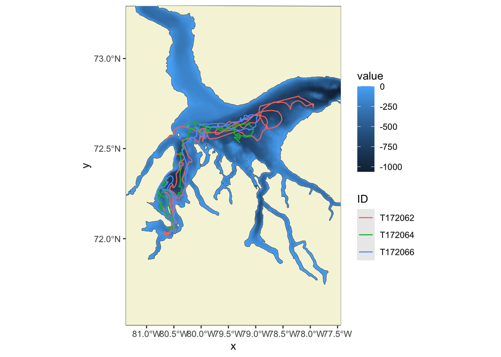

```r
ggplot() +
  geom_spatraster(data = bathy) +
  geom_sf(data = land, fill = "beige") +
  geom_spatial_path(data = tracks_gps_O,
                    aes(x = x, y = y, colour = ID), crs = 4326) +
  coord_sf(expand = FALSE)
```

As we will see during the week, many analyses require that the locations are at regular time intervals, however Fastloc GPS data is often taken at irregular time intervals, since it depends on when the animal surface. When the data is irregular, there are two key decisions we must make, (1) the temporal resolution to use, and (2) how to address large data gaps.